# NBA Birthday Analysis

McCade Pearson

2025-06-30

```r
legs <- sort(c(rep(seq(1, 7), 10), rep(8, 12)))
getPoints <- function(wins) {
  case_when(wins == 0 ~ 0,
            wins == 1 ~ 1,
            wins == 2 ~ 1,
            wins == 3 ~ 2,
            wins == 4 ~ 2,
            wins == 5 ~ 3,
            wins == 6 ~ 3,
            wins == 7 ~ 4,
            wins == 8 ~ 4,
            wins == 9 ~ 5,
            wins == 10 ~ 5,
            wins == 11 ~ 6,
            wins == 12 ~ 6)}
getPoints2 <- function(wins) {
  case_when(wins == 0 ~ 0,
            wins == 1 ~ 1,
            wins == 2 ~ 2,
            wins == 3 ~ 4,
            wins == 4 ~ 6,
            wins == 5 ~ 9,
            wins == 6 ~ 12,
            wins == 7 ~ 16,
            wins == 8 ~ 20,
            wins == 9 ~ 25,
            wins == 10 ~ 30,
            wins == 11 ~ 36,
            wins == 12 ~ 42)}
all_schedule <- hoopR::load_nba_schedule()
all_schedule <- all_schedule %>%
  mutate(date = lubridate::ymd_hm(date)-28800) %>%
  filter(type_abbreviation == "STD") %>%
  filter(season_type == 2) %>%
  filter(status_type_id == 3)
east <- c("MIL", "BOS", "PHI", "CLE", "BKN", "NY", "MIA", "DET", "ATL", "TOR", "WSH", "IND", "CHI", "ORL", "CHA")
Teams <- all_schedule %>%
  select(home_name, home_color, home_logo, home_color, home_alternate_color, home_display_name, home_abbreviation) %>%
  distinct()
```

```r
get_schedule <- function(TeamName) {
  HomeGames <- all_schedule %>%
  filter(home_name == TeamName) %>%
  select(date, home_name, home_score, away_name, away_abbreviation, away_logo, away_score, away_color, away_alternate_color, game_id) %>%
  mutate(Team = home_name,
         TeamScore = home_score,
         OpponentScore = away_score,
         Opponent = away_name,
         Opponent2 = away_abbreviation,
         OpponentLogo = away_logo) %>%
  mutate(TeamWin = ifelse(home_score > away_score, 1, 0),
         Game = "Home") %>%
  select(date, Team, TeamScore, OpponentScore, Opponent, Opponent2, OpponentLogo,TeamWin, Game, game_id)
AwayGames <- all_schedule %>%
  filter(away_name == TeamName) %>%
  select(date, away_name, away_score, home_name, home_abbreviation, home_logo, home_score, home_color, home_alternate_color, game_id) %>%
  mutate(Team = away_name,
         TeamScore = away_score,
         OpponentScore = home_score,
         Opponent = home_name,
         Opponent2 = home_abbreviation,
         OpponentLogo = home_logo) %>%
  mutate(TeamWin = ifelse(away_score > home_score, 1, 0),
         Game = "Away") %>%
  select(date, Team, TeamScore, OpponentScore, Opponent, Opponent2, OpponentLogo, TeamWin, Game, game_id)
Games <- rbind(HomeGames, AwayGames)
Games <- Games %>%
  arrange((date)) %>%
  mutate(Leg = legs) %>%
  group_by(Leg) %>%
  mutate(RunWins = cumsum(TeamWin),
         Points = ifelse(TeamWin == 1, getPoints(RunWins), 0),
         PointsPlaying = ifelse(TeamWin == 1, getPoints(RunWins), getPoints(RunWins+1)),
         GameLeg = 1:n()) %>%
  ungroup() %>%
  mutate(RunningPts = cumsum(Points))
return(Games)}
Schedules <- list()
for (team in Teams$home_name) {
  Schedules[[team]] <- get_schedule(team)}
```

```r
#months <- 1:12
#days_in_month <- c(31, 28, 31, 30, 31, 30, 31, 31, 30, 31, 30, 31)
#
#Tables <- data.frame()
#
#for (month in months) {
#  for (day in 1:days_in_month[month]) {
#    filmURL <- read_html(paste("https://www.basketball-reference.com/friv/birthdays#.fcgi?month=", month, "&day=", day, sep = ""))
#    allTables <- filmURL %>%
#      html_table(fill = TRUE)
#    Results <- allTables[[1]]
#    Results <- Results %>%
#      row_to_names(row_number = 1) %>%
#      clean_names()
#    Results$month <- month
#    Results$day <- day
#    Results <- Results %>%
#      filter(player != "Player") %>%
#      filter(player != "")
#    Tables <- rbind(Results,Tables)
#    print(paste(month, day, Sys.time(), sep = "-"))
#    Sys.sleep(1.5)}}
Tables <- read.csv("AllPlayers.csv")
```

```r
Tables2 <- Tables %>%
  mutate(
    player = str_remove(player, "\\*$"),
    rk = as.numeric(rk),
    yrs = as.numeric(yrs),
    g = as.numeric(g),
    mp = as.numeric(mp),
    fg = as.numeric(fg),
    fga = as.numeric(fga),
    x3p = as.numeric(x3p),
    x3pa = as.numeric(x3pa),
    ft = as.numeric(ft),
    fta = as.numeric(fta),
    orb = as.numeric(orb),
    trb = as.numeric(trb),
    ast = as.numeric(ast),
    stl = as.numeric(stl),
    blk = as.numeric(blk),
    tov = as.numeric(tov),
    pf = as.numeric(pf),
    pts = as.numeric(pts),
    ws = as.numeric(ws),
    fg_percent = as.numeric(fg_percent),
    x3p_percent = as.numeric(x3p_percent),
    ft_percent = as.numeric(ft_percent),
    mp_2 = as.numeric(mp_2),
    pts_2 = as.numeric(pts_2),
    trb_2 = as.numeric(trb_2),
    ast_2 = as.numeric(ast_2),
    doy = yday(make_date(year = 2001, month = month, day = day)))

Tables3 <- Tables2 %>%
  filter(g >= 100) %>%
  filter(born >= 1935) %>%
  group_by(doy) %>%
  mutate(RkPts = rank(-pts, ties.method = "random"),
         RkReb = rank(-trb, ties.method = "random"),
         RkAst = rank(-ast, ties.method = "random"),
         WSp48 = ws/mp*48,
         RkWS48 = rank(-WSp48, ties.method = "random")) %>%
  select(player, born, g, pts, trb, ast, WSp48, RkPts, RkReb, RkAst, RkWS48, doy, month, day) %>%
  ungroup()
```

```r
GetDatesPts <- Tables3 %>%
  filter(RkPts == 1) %>%
  rowwise() %>%
  mutate(Window = list(((doy - 2):(doy + 2) - 1) %% 365 + 1)) %>%
  unnest(Window) %>%
  select(Window, pts)
RkPts <- Tables3 %>%
  filter(RkPts == 1) %>%
  left_join(GetDatesPts, by = c('doy' = 'Window')) %>%
  group_by(doy) %>%
  mutate(pts.z = sum(pts.y)) %>%
  ungroup() %>%
  arrange(-pts.z) %>%
  select(doy, pts.z) %>%
  head(1)
Doy <- RkPts$doy[1]
Value <- RkPts$pts.z[1]
PtsResults <- Tables3 %>%
  filter(RkPts == 1) %>%
  filter(doy >= Doy-2 & doy <= Doy+2) %>%
  arrange(month,day) %>%
  mutate(date = paste0(month.abb[month], " ", day, ", ", born),
         Pic = c("https://www.basketball-reference.com/req/202106291/images/headshots/chambwi01.jpg","https://www.basketball-reference.com/req/202106291/images/headshots/catlete01.jpg","https://www.basketball-reference.com/req/202106291/images/headshots/bryanko01.jpg","https://www.basketball-reference.com/req/202106291/images/headshots/millere01.jpg","https://www.basketball-reference.com/req/202106291/images/headshots/horryro01.jpg")) %>%
  select(date, Pic, player, pts)


gt(PtsResults) %>%
  gt_theme_espn() %>%
  text_transform(locations = cells_body(columns = Pic),
      fn = function(x) {web_image(url = PtsResults$Pic, height = as.numeric(40))}) %>%
  cols_align(align = c('center')) %>%
  cols_label(date = "Birthday",
             player = "Player",
             pts = "Points",
             Pic = "") %>%
  tab_header(title = md("**The Best Five-Day Run of Basketball Birthdays**"),
             subtitle = md("104,576 Points")) %>%
  opt_align_table_header(align = c('center')) %>%
  tab_source_note(source_note = "@McCadeP8 | Data: basketball-reference") %>%
  fmt_number(columns = c(pts), use_seps = T, decimals = 0)
```

**The Best Five-Day Run of Basketball Birthdays**

104,576 Points

Birthday

Player

Points

Aug 21, 1936

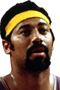

Wilt Chamberlain

31,419

Aug 22, 1963

[figure not shown]

Terry Catledge

6,520

Aug 23, 1978

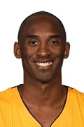

Kobe Bryant

33,643

Aug 24, 1965

[figure not shown]

Reggie Miller

25,279

Aug 25, 1970

[figure not shown]

Robert Horry

7,715

@McCadeP8 | Data: basketball-reference

```r
GetDatesReb <- Tables3 %>%
  filter(RkReb == 1) %>%
  rowwise() %>%
  mutate(Window = list(((doy - 2):(doy + 2) - 1) %% 365 + 1)) %>%
  unnest(Window) %>%
  select(Window, trb)
RkReb <- Tables3 %>%
  filter(RkReb == 1) %>%
  left_join(GetDatesReb, by = c('doy' = 'Window')) %>%
  group_by(doy) %>%
  mutate(trb.z = sum(trb.y)) %>%
  ungroup() %>%
  arrange(-trb.z) %>%
  select(doy, trb.z) %>%
  head(1)
Doy <- RkReb$doy[1]
Value <- RkReb$trb.z[1]
RebResults <- Tables3 %>%
  filter(RkReb == 1) %>%
  filter(doy >= Doy-2 & doy <= Doy+2) %>%
  arrange(month,day) %>%
  select(player, born, trb, month, day)

GetDatesAst <- Tables3 %>%
  filter(RkAst == 1) %>%
  rowwise() %>%
  mutate(Window = list(((doy - 2):(doy + 2) - 1) %% 365 + 1)) %>%
  unnest(Window) %>%
  select(Window, ast)
RkAst <- Tables3 %>%
  filter(RkAst == 1) %>%
  left_join(GetDatesAst, by = c('doy' = 'Window')) %>%
  group_by(doy) %>%
  mutate(ast.z = sum(ast.y)) %>%
  ungroup() %>%
  arrange(-ast.z) %>%
  select(doy, ast.z) %>%
  head(1)
Doy <- RkAst$doy[1]
Value <- RkAst$ast.z[1]
AstResults <- Tables3 %>%
  filter(RkAst == 1) %>%
  filter(doy >= Doy-2 & doy <= Doy+2) %>%
  arrange(month,day) %>%
  left_join(RebResults, by = c('month', 'day')) %>%
  mutate(date = paste0(month.abb[month], " ", day),
         Pic.x = c("https://www.basketball-reference.com/req/202106291/images/headshots/shawbr01.jpg","https://www.basketball-reference.com/req/202106291/images/headshots/kiddja01.jpg","https://www.basketball-reference.com/req/202106291/images/headshots/fordtj01.jpg","https://www.basketball-reference.com/req/202106291/images/headshots/lowryky01.jpg","https://www.basketball-reference.com/req/202106291/images/headshots/stockjo01.jpg"),
         Pic.y = c("https://www.basketball-reference.com/req/202106291/images/headshots/cambyma01.jpg","https://www.basketball-reference.com/req/202106291/images/headshots/malonmo01.jpg","https://www.basketball-reference.com/req/202106291/images/headshots/boshch01.jpg","https://www.basketball-reference.com/req/202106291/images/headshots/davisda01.jpg","https://www.basketball-reference.com/req/202106291/images/headshots/embrywa01.jpg")) %>%
  select(date, born.x, Pic.x, player.x, ast, born.y, Pic.y, player.y, trb.y)

gt(AstResults) %>%
  gt_theme_espn() %>%
  text_transform(locations = cells_body(columns = Pic.x),
      fn = function(x) {web_image(url = AstResults$Pic.x, height = as.numeric(40))}) %>%
    text_transform(locations = cells_body(columns = Pic.y),
      fn = function(x) {web_image(url = AstResults$Pic.y, height = as.numeric(40))}) %>%
  cols_align(align = c('center')) %>%
  cols_label(date = "Birthday",
             born.x = "Year",
             born.y = "Year",
             player.x = "Player",
             player.y = "Player",
             trb.y = "Rebounds",
             ast = "Assists",
             Pic.x = "",
             Pic.y = "") %>%
  tab_header(title = md("**The Best Five-Day Run of Basketball Birthdays**"),
             subtitle = md("Remarkably, both lineups fall on March 22–26—yet share no players in common")) %>%
  opt_align_table_header(align = c('center')) %>%
  tab_source_note(source_note = "@McCadeP8 | Data: basketball-reference") %>%
  fmt_number(columns = c(ast,trb.y), use_seps = T, decimals = 0) %>%
  tab_spanner(label = "41,409 Assists", columns = c(born.x, player.x, Pic.x, ast)) %>%
  tab_spanner(label = "51,088 Rebounds", columns = c(born.y, player.y, Pic.y, trb.y))
```

**The Best Five-Day Run of Basketball Birthdays**

Remarkably, both lineups fall on March 22–26—yet share no players in common

Birthday

41,409 Assists

51,088 Rebounds

Year

Player

Assists

Year

Player

Rebounds

Mar 22

1966

Brian Shaw

[figure not shown]

3,918

1974

Marcus Camby

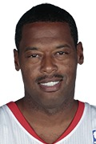

9,513

Mar 23

1973

Jason Kidd

[figure not shown]

12,091

1955

Moses Malone

[figure not shown]

17,834

Mar 24

1983

T.J. Ford

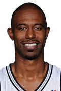

2,495

1984

Chris Bosh

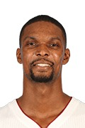

7,592

Mar 25

1986

Kyle Lowry

[figure not shown]

7,099

1969

Dale Davis

[figure not shown]

8,605

Mar 26

1962

John Stockton

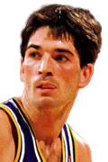

15,806

1937

Wayne Embry

[figure not shown]

7,544

@McCadeP8 | Data: basketball-reference

```r
GetDatesWS <- Tables3 %>%
  filter(RkWS48 == 1) %>%
  rowwise() %>%
  mutate(Window = list(((doy - 2):(doy + 2) - 1) %% 365 + 1)) %>%
  unnest(Window) %>%
  select(Window, WSp48)
RkWS <- Tables3 %>%
  filter(RkWS48 == 1) %>%
  left_join(GetDatesWS, by = c('doy' = 'Window')) %>%
  group_by(doy) %>%
  mutate(WSp48.z = sum(WSp48.y)) %>%
  ungroup() %>%
  arrange(-WSp48.z) %>%
  select(doy, WSp48.z) %>%
  head(1)
Doy <- RkWS$doy[1]
Value <- RkWS$WSp48.z[1]
WSResults <- Tables3 %>%
  filter(RkWS48 == 1) %>%
  filter(doy >= Doy-2 & doy <= Doy+2) %>%
  arrange(month,day) %>%
  mutate(date = paste0(month.abb[month], " ", day, ", ", born),
         WSp48 = round(WSp48,4),
         Pic = c("https://www.basketball-reference.com/req/202106291/images/headshots/jordami01.jpg","https://www.basketball-reference.com/req/202106291/images/headshots/kirilan01.jpg","https://www.basketball-reference.com/req/202106291/images/headshots/jokicni01.jpg","https://www.basketball-reference.com/req/202106291/images/headshots/barklch01.jpg","https://www.basketball-reference.com/req/202106291/images/headshots/francst01.jpg")) %>%
  select(date, Pic, player, WSp48)

gt(WSResults) %>%
  gt_theme_espn() %>%
  text_transform(locations = cells_body(columns = Pic),
      fn = function(x) {web_image(url = WSResults$Pic, height = as.numeric(40))}) %>%
  cols_align(align = c('center')) %>%
  cols_label(date = "Birthday",
             player = "Player",
             WSp48 = "WS per 48min",
             Pic = "") %>%
  tab_header(title = md("**The Strongest Five-Day Birthday Lineup in Basketball**")) %>%
  opt_align_table_header(align = c('center')) %>%
  tab_source_note(source_note = "@McCadeP8 | Data: basketball-reference")
```

**The Strongest Five-Day Birthday Lineup in Basketball**

Birthday

Player

WS per 48min

Feb 17, 1963

[figure not shown]

Michael Jordan

0.2505

Feb 18, 1981

[figure not shown]

Andrei Kirilenko

0.1513

Feb 19, 1995

[figure not shown]

Nikola Jokić

0.2598

Feb 20, 1963

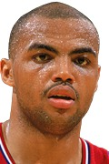

Charles Barkley

0.2163

Feb 21, 1977

[figure not shown]

Steve Francis

0.1200

@McCadeP8 | Data: basketball-reference

[figure not shown]

```r
Total <- Tables2 %>%
  group_by(doy) %>%
  summarize(TotalG = sum(g, na.rm = TRUE))
Total2 <- Total %>%
  rowwise() %>%
  mutate(Window = list(((doy - 15):(doy + 15) - 1) %% 365 + 1)) %>%
  unnest(Window) %>%
  group_by(Window) %>%
  summarise(AvgG = mean(TotalG, na.rm = TRUE), .groups = "drop") %>%
  left_join(Total, by = c("Window" = "doy"))

ggplot(Total2) +
  geom_vline(xintercept = c(1, 32, 60, 91, 121, 152, 182, 213, 244, 274, 305, 335, 365), color = "#1D3557", linewidth = 0.5) +
  geom_point(aes(x = Window, y = TotalG), color = "#C3DDFD", alpha = 0.6) +
  geom_segment(aes(x = Window, xend = Window, y = AvgG, yend = TotalG), color = "#C3DDFD", alpha = 0.6) +
  geom_line(aes(x = Window, y = AvgG), color = "#326DA8", size = 2) +
  geom_segment(aes(x = 90, y = 11379, xend = 58, yend = 11379), arrow = arrow(length = unit(0.5, "cm"), type = "closed"), color = "#C3DDFD", size = 1) +
  geom_segment(aes(x = 330, y = 350, xend = 358, yend = 313), arrow = arrow(length = unit(0.5, "cm"), type = "closed"), color = "#C3DDFD", size = 1) +
  geom_segment(aes(x = 150, y = 8750, xend = 73, yend = 4900), arrow = arrow(length = unit(0.5, "cm"), type = "closed"), color = "#326DA8", size = 1) +
  geom_segment(aes(x = 249, y = 8750, xend = 249, yend = 4800), arrow = arrow(length = unit(0.5, "cm"), type = "closed"), color = "#326DA8", size = 1) +
  geom_label(aes(x = 75, y = 11379, label = "11,379 games played — Dr. J & Chet Walker (HoF), Rondo, Van Arsdale twins"), hjust = 0, size = 6.3, fill = "#C3DDFD") +
  geom_label(aes(x = 240, y = 8750, label = "Peak driven by kids born early in the calendar or school year, who had early physical advantages"), size = 6.2, fill = "#326DA8", color = "white") +
  geom_label(aes(x = 345, y = 350, label = "Only one player born this day since 1955: Briante Weber (45 games)"), hjust = 1, size = 6.2, fill = "#C3DDFD") +
  scale_x_continuous(limits = c(0, 366), breaks = c(16, 46, 75.5, 106, 136.5, 167, 197.5, 228.5, 259, 289.5, 320, 350), labels = c("Jan", "Feb", "Mar", "Apr", "May", "Jun", "Jul", "Aug", "Sep", "Oct", "Nov", "Dec")) +
  scale_y_continuous(limits = c(0, 12500), breaks = c(0, 2500, 5000, 7500, 10000, 12500), expand = c(0, 0), labels = comma) +
  labs(x = "",
       y = "Career Games Played",
       title = "Most Career Games Played by Birthday",
       caption = "@McCadeP8 | Data: basketball-reference") +
  theme_McCadeP8() +
  theme(panel.grid.major = element_blank(), panel.grid.minor = element_blank(), plot.title = element_text(face = "bold", size = 24, hjust = 0.5))
```